# Sviluppare agenti di intelligenza artificiale in Azure

## 8.4 Usare l’orchestrazione simultanea

L’orchestrazione simultanea consente a più agenti di lavorare contemporaneamente sulla stessa attività. Ogni agente gestisce l’attività in modo indipendente e quindi i relativi output vengono raccolti e combinati. Questo metodo funziona particolarmente bene quando si vogliono approcci o soluzioni diversi, ad esempio durante il brainstorming, il processo decisionale del gruppo o il voto.

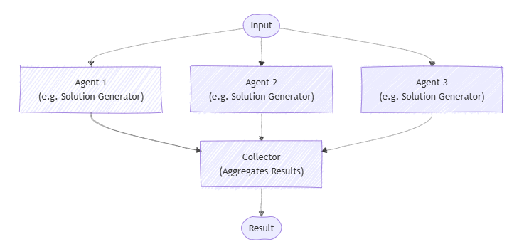

Questo modello è utile quando sono necessari approcci o idee diversi per risolvere lo stesso problema. Invece di fare in modo che gli agenti lavorino uno dopo l’altro, lavorano tutti contemporaneamente. Questo accelera il processo e copre il problema da molte angolazioni.

In genere, i risultati di ogni agente vengono combinati per creare una risposta finale, ma questo non è sempre necessario. Ogni agente può anche produrre un risultato separato, ad esempio chiamare gli strumenti per completare le attività o aggiornare archivi dati diversi in modo indipendente.

Gli agenti lavorano autonomamente e non condividono i risultati tra loro. Tuttavia, un agente può chiamare altri agenti di intelligenza artificiale eseguendo la propria orchestrazione come parte del processo. Gli agenti devono sapere quali altri agenti sono disponibili per lavorare sulle attività. Questo modello consente di chiamare tutti gli agenti registrati ogni volta o di scegliere gli agenti da eseguire in base all’attività specifica.

### 8.4.1 Quando usare l’orchestrazione simultanea

È possibile prendere in considerazione l’uso del modello di orchestrazione simultanea in queste situazioni:

- uando le attività possono essere eseguite contemporaneamente, usando un gruppo fisso di agenti o selezionando gli agenti di intelligenza artificiale in modo dinamico in base alle esigenze dell’attività.
- Quando l’attività trae vantaggio da diverse competenze o approcci specializzati (ad esempio, tecnici, aziendali o creativi) che tutti lavorano in modo indipendente, ma contribuiscono a risolvere lo stesso problema.

Questo tipo di lavoro in team è comune nei metodi decisionali multi-agente, ad esempio:

- Idee di brainstorming
- Combinazione di metodi di ragionamento diversi (ragionamento dell’insieme)
- Prendere decisioni in base al voto o al consenso (quorum)
- La gestione delle attività in cui la velocità è importante e gli agenti in esecuzione in parallelo riduce il tempo di attesa

### 8.4.2 Quando evitare l’orchestrazione simultanea

È consigliabile evitare di usare il modello di orchestrazione simultanea negli scenari seguenti:

- Gli agenti devono basarsi sul lavoro dell’altro o dipendono dal contesto condiviso in un ordine specifico.
- L’attività richiede una sequenza rigorosa di passaggi o risultati ripetibili prevedibili.
- I limiti delle risorse, ad esempio le quote di utilizzo del modello, rendono gli agenti in esecuzione in parallelo inefficienti o impossibili.
- Gli agenti non possono coordinare in modo affidabile le modifiche ai dati condivisi o ai sistemi esterni durante l’esecuzione contemporaneamente.
- Non esiste un modo chiaro per risolvere i conflitti o le contraddizioni tra i risultati di agenti diversi.
- La combinazione dei risultati è troppo complicata o finisce per abbassare la qualità complessiva.

### 8.4.3 Implementare l’orchestrazione simultanea

Implementare il modello di orchestrazione simultanea con Microsoft Agent Framework:

1. **Creare il client di chat**: Configurare un client di chat (ad esempio, AzureOpenAIChatClient) con le credenziali appropriate per connettersi al provider di servizi di intelligenza artificiale.
2. **Definire gli agenti**: Creare istanze di agenti utilizzando il metodo create_agent del client di chat. Ogni agente deve avere istruzioni specifiche e un nome che ne definisce il ruolo e l’area di competenza.
3. **Creare il flusso di lavoro simultaneo**: Usare la ConcurrentBuilder classe per creare un flusso di lavoro in grado di eseguire più agenti in parallelo. Aggiungi le istanze dell’agente come partecipanti usando il metodo participants(), quindi chiama build() per creare il flusso di lavoro.
4. **Eseguire il flusso di lavoro**: Chiamare il metodo del flusso di lavoro run con l’attività o l’input su cui si desidera che gli agenti lavorino. Il flusso di lavoro esegue tutti gli agenti simultaneamente e restituisce eventi contenenti i risultati.
5. **Elaborare i risultati**: Estrarre gli output dagli eventi del flusso di lavoro usando get_outputs(). I risultati contengono le conversazioni combinate di tutti gli agenti, con la risposta di ogni agente inclusa nell’output finale.
6. **Gestire le risposte aggregate**: Elaborare i messaggi aggregati da tutti gli agenti. Ogni messaggio include il nome e il contenuto dell’autore, consentendo di identificare l’agente che ha fornito ogni risposta.

L’orchestrazione simultanea è un modello potente per l’uso simultaneo di più agenti di intelligenza artificiale, consentendo la risoluzione dei problemi più rapida e diversificata. Eseguendo agenti in parallelo, è possibile esplorare diversi approcci contemporaneamente, migliorare l’efficienza e ottenere informazioni più dettagliate. Tuttavia, è importante scegliere questo modello quando le attività possono essere effettivamente eseguite in modo indipendente e tenere conto dei vincoli delle risorse e delle sfide di coordinamento. Se implementata in modo ponderato con Microsoft Agent Framework SDK, l’orchestrazione simultanea può migliorare notevolmente i flussi di lavoro di intelligenza artificiale e i processi decisionali.

## 8.5 Usare l’orchestrazione sequenziale

Nell’orchestrazione sequenziale, gli agenti vengono disposti in una pipeline in cui ogni agente elabora l’attività una dopo l’altra. L’output di un agente diventa l’input per il successivo. Questo modello è ideale per i flussi di lavoro in cui ogni passaggio dipende da quello precedente, ad esempio la revisione dei documenti, le pipeline di trasformazione dei dati o il ragionamento a più fasi.

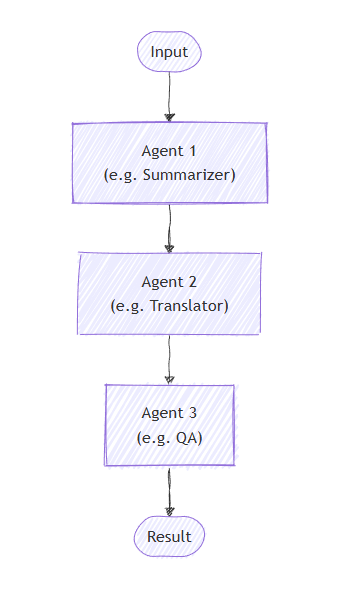

L’orchestrazione sequenziale funziona meglio per le attività che devono essere eseguite passo dopo passo, con ogni passaggio che migliora l’ultimo. L’ordine in cui gli agenti vengono eseguiti è fisso e deciso in anticipo. Gli agenti non decidono cosa succederà successivamente.

### 8.5.1 Quando usare l’orchestrazione sequenziale

Prendere in considerazione l’uso del modello di orchestrazione sequenziale quando il flusso di lavoro ha:

- Processi costituiti da più passaggi che devono essere eseguiti in un ordine specifico, in cui ogni passaggio si basa su quello prima.
- Flussi di lavoro di dati in cui ogni fase aggiunge qualcosa di importante che la fase successiva deve funzionare correttamente.
- Attività in cui le fasi non possono essere eseguite contemporaneamente e devono essere eseguite una dopo l’altra.
- Situazioni che richiedono miglioramenti graduali, ad esempio la stesura, la revisione e la lucidatura del contenuto.
- Sistemi in cui si conoscono le prestazioni di ogni agente e possono gestire ritardi o errori in qualsiasi passaggio senza arrestare l’intero processo.

### 8.5.2 Quando evitare l’orchestrazione sequenziale

Evitare questo modello quando:

- Le fasi possono essere eseguite in modo indipendente e in parallelo senza influire sulla qualità.
- Un singolo agente può eseguire l’intera attività in modo efficace.
- Le fasi iniziali possono non riuscire o produrre output scarso e non è possibile arrestare o correggere l’elaborazione downstream in base agli errori.
- Gli agenti devono collaborare in modo dinamico anziché consegnare il lavoro in sequenza.
- Il flusso di lavoro richiede iterazione, backtracking o routing dinamico in base ai risultati intermedi.

### 8.5.3 Implementare l’orchestrazione sequenziale

Implementare il modello di orchestrazione sequenziale con Microsoft Agent Framework SDK:

1. **Creare il client di chat**: Configurare un client di chat (ad esempio, AzureOpenAIChatClient) con le credenziali appropriate per connettersi al provider di servizi di intelligenza artificiale.
2. **Definire gli agenti**: Creare istanze di agenti utilizzando il metodo create_agent del client di chat. Ogni agente deve avere istruzioni specifiche e un nome che ne definisce il ruolo e l’area di competenza nella pipeline.
3. **Compilare il flusso di lavoro sequenziale**: Usare la SequentialBuilder classe per creare un flusso di lavoro che esegue gli agenti uno dopo l’altro. Aggiungi le istanze dell’agente come partecipanti usando il metodo participants(), quindi chiama build() per creare il flusso di lavoro.
4. **Eseguire il flusso di lavoro**: Chiamare il metodo del flusso di lavoro run_stream con l’attività o l’input su cui si desidera che gli agenti lavorino. Il flusso di lavoro elabora l’attività tramite tutti gli agenti in sequenza, con l’output di ogni agente che diventa input per il successivo.
5. **Elaborare gli eventi del flusso di lavoro**: Scorrere gli eventi del flusso di lavoro usando un ciclo asincrono. WorkflowOutputEvent Cercare le istanze che contengono i risultati dell’elaborazione sequenziale.
6. **Estrarre la conversazione finale**: Raccogliere la conversazione finale dagli output del flusso di lavoro. Il risultato contiene la cronologia di conversazione completa che mostra come ogni agente nella sequenza ha contribuito al risultato finale.

L’orchestrazione sequenziale è ideale quando l’attività richiede passaggi chiari e ordinati in cui ogni agente si basa sull’output precedente. Questo modello consente di migliorare la qualità dell’output tramite perfezionamento passo per passo e garantisce flussi di lavoro prevedibili. Se applicato con l’SDK di Microsoft Agent Framework, consente potenti pipeline multi-agente per attività complesse come la creazione di contenuti, l’elaborazione dei dati e altro ancora.

## 8.6 Usare l’orchestrazione di chat di gruppo

L’**orchestrazione di chat di gruppo** modella una conversazione collaborativa tra più agenti di intelligenza artificiale e, facoltativamente, un partecipante umano. Un gestore di chat centrale controlla il flusso, decidendo quale agente risponde successivamente e quando richiedere l’input umano. Questo modello è utile per simulare riunioni, dibattiti o risoluzione collaborativa dei problemi.

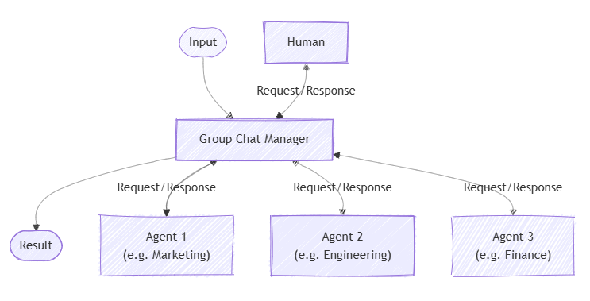

Il modello di chat di gruppo funziona bene per gli scenari in cui la discussione di gruppo o la collaborazione iterativa è fondamentale per prendere decisioni. Supporta diversi stili di interazione, dall’ideazione a flusso libero ai flussi di lavoro formali con ruoli definiti e passaggi di approvazione. L’orchestrazione di chat di gruppo è ideale anche per le configurazioni umane nel ciclo in cui un essere umano può guidare o intervenire nella conversazione. In genere, gli agenti in questo modello non modificano direttamente i sistemi in esecuzione, ma contribuiscono principalmente alla conversazione.

### 8.6.1 Quando usare l’orchestrazione di chat di gruppo

È consigliabile usare l’orchestrazione di chat di gruppo quando lo scenario prevede:

- Collaborazione spontanea o guidata tra agenti (ed eventualmente umani)
- Cicli iterativi del controllo degli autori in cui gli agenti si trasformano nella creazione e nella revisione degli agenti
- Supervisione o partecipazione umana in tempo reale
- Conversazioni trasparenti e controllabili poiché tutto l’output viene raccolto in un singolo thread

Gli scenari comuni includono:

- Brainstorming creativo in cui gli agenti si basano sulle idee dell’altro
- Processo decisionale che trae vantaggio dal dibattito e dal consenso
- Problemi complessi che richiedono un dialogo multidisciplinare
- Controllo della qualità e convalida che richiedono più prospettive di esperti
- Flussi di lavoro del contenuto con netta separazione tra la creazione e la revisione

### 8.6.2 Quando evitare l’orchestrazione di chat di gruppo

Evitare questo modello quando:

- La delega di attività semplice o le pipeline lineari semplici sono sufficienti
- I requisiti di velocità in tempo reale rendono poco pratico il sovraccarico di discussione
- I flussi di lavoro gerarchici o deterministici sono necessari senza discussione
- Il gestore di chat non è in grado di determinare chiaramente quando l’attività è stata completata
- La gestione del flusso di conversazione diventa troppo complessa, soprattutto con molti agenti (limite a tre o meno per un controllo più semplice)

### 8.6.3 Cicli maker-checker

Un caso speciale comune è il ciclo maker-checker. Qui, un agente (l’autore) propone contenuti o soluzioni, e un altro agente (il controllo) li critica e li critica. Il controllo può inviare commenti e suggerimenti all’autore e questo ciclo si ripete fino a quando il risultato non è soddisfacente. Questo processo richiede una sequenza basata su turni gestita dal gestore di chat.

### 8.6.5 Personalizzazione del gestore di chat di gruppo

È possibile creare un gestore di chat di gruppo personalizzato estendendo la classe base GroupChatManager. Questo approccio consente di controllare:

- Come vengono filtrati o riepilogati i risultati della conversazione
- Modalità di selezione dell’agente successivo
- Quando richiedere l’input dell’utente
- Quando terminare la conversazione

I responsabili personalizzati consentono di implementare logica specializzata personalizzata per il caso d’uso.

### 8.6.6 Ordine di chiamata di Gestione chat di gruppo

Durante ogni round della conversazione, il gestore di chat chiama i metodi in questo ordine:

1. `should_request_user_input` - Controlla se l’input umano è necessario prima che l’agente successivo risponda.
2. `should_terminate` - Determina se la conversazione deve terminare (ad esempio, è stato raggiunto il numero massimo di round).
3. `filter_results` - Se termina, riepiloga o elabora la conversazione finale.
4. `select_next_agent` - Se continua, sceglie l’agente successivo da pronunciare.

Ciò garantisce che le condizioni di input e terminazione dell’utente vengano gestite prima di spostare la conversazione in avanti. Eseguire l’override di questi metodi nel gestore personalizzato per modificare il comportamento.

L’orchestrazione di chat di gruppo consente a più agenti di intelligenza artificiale, e facoltativamente agli esseri umani, di collaborare tramite conversazione guidata e feedback iterativo. È ideale per attività complesse che traggono vantaggio da diverse competenze e interazione dinamica. Anche se richiede un’attenta gestione, questo modello offre trasparenza e flessibilità nei flussi di lavoro decisionali e creativi. Microsoft Agent Framework SDK semplifica l’implementazione e la personalizzazione dell’orchestrazione di chat di gruppo per le proprie esigenze.

## 8.7 Usare l’orchestrazione del passaggio

L’orchestrazione del passaggio consente agli agenti di intelligenza artificiale di trasferirsi il controllo a vicenda in base al contesto dell’attività o alle richieste degli utenti. Ogni agente può “consegnare” la conversazione a un altro agente con la giusta esperienza, assicurandosi che l’agente più adatto gestisca ogni parte dell’attività. Questo modello è ideale per il supporto clienti, i sistemi esperti o qualsiasi situazione in cui è necessaria la delega dinamica.

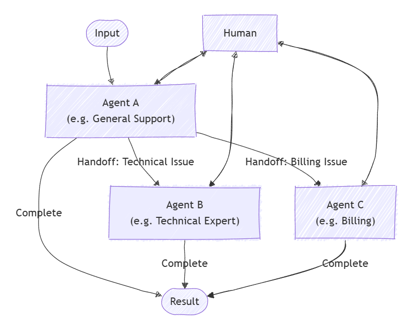

Questo modello si adatta agli scenari in cui l’agente migliore non è noto in anticipo o in cui i requisiti dell’attività diventano più chiari durante l’elaborazione. A differenza dei modelli paralleli, gli agenti lavorano uno alla volta, passando completamente il controllo da uno a quello successivo.

### 8.7.1 Quando usare l’orchestrazione del passaggio

Potresti prendere in considerazione l’uso del modello di orchestrazione di trasferimento in questi scenari:

- Le attività richiedono conoscenze o strumenti specializzati, ma il numero o l’ordine degli agenti non possono essere determinati in anticipo.
- I requisiti di competenza emergono dinamicamente durante l’elaborazione, attivando il routing delle attività in base all’analisi del contenuto.
- I problemi a più domini richiedono specialisti diversi che lavorano in sequenza.
- È possibile definire segnali chiari o regole che indicano quando un agente deve trasferire il controllo e a chi.

### 8.7.2 Quando evitare l’orchestrazione del passaggio

È consigliabile evitare di usare il modello di orchestrazione del passaggio in questi scenari:

- Gli agenti coinvolti e il loro ordine sono noti in anticipo e fissi.
- Il routing delle attività è semplice e basato su regole, non richiede l’interpretazione dinamica.
- Le decisioni di routing scarse potrebbero frustrare gli utenti.
- Più operazioni devono essere eseguite contemporaneamente.
- Evitare cicli di passaggio infiniti o un rimbalzo eccessivo tra gli agenti è difficile.

### 8.7.3 Implementazione dell’orchestrazione del passaggio

Il modello di orchestrazione handoff può essere implementato in Microsoft Agent Framework SDK usando flussi di lavoro di controllo. In un flusso di lavoro di controllo ogni agente elabora l’attività in sequenza e, in base all’output, il flusso di lavoro decide quale agente chiamare successivamente. Questo routing viene eseguito tramite una struttura switch-case che indirizza l’attività a diversi agenti in base ai risultati della classificazione.

1. Configurare modelli di dati e client di chat
   - Creare il client di chat per la connessione ai servizi di intelligenza artificiale
   - Definire i modelli Pydantic per le risposte JSON strutturate degli agenti di intelligenza artificiale
   - Creare classi di dati semplici per il passaggio di informazioni tra i passaggi del flusso di lavoro
   - Configurare gli agenti con istruzioni e response_format parametri specifici per l’output JSON strutturato
2. Creare funzioni executor specializzate
   - Esecutore di archiviazione di input - salva i dati in ingresso nello stato condiviso e li inoltra all’agente di classificazione.
   - Esecutore della trasformazione: converte la risposta JSON dell’agente in un oggetto di routing tipizzato
   - Esecutori del gestore - esecutori separati per ogni risultato di classificazione con condizioni di protezione per verificare l’elaborazione corretta dei messaggi
3. Compilare la logica di routing
   - Creare funzioni factory che generano controlli delle condizioni per ogni valore di classificazione
   - Progettare condizioni per esaminare i messaggi in arrivo e restituire il valore “vero” per risultati di classificazione specifici
   - Usare le condizioni con gli oggetti Case nei gruppi di edge switch-case
   - Includere sempre un caso predefinito come soluzione alternativa per scenari imprevisti.
4. Assemblare il flusso di lavoro
   - Usare WorkflowBuilder per connettere gli esecutori con edge regolari
   - Aggiungere un gruppo edge switch case per il routing in base ai risultati della classificazione
   - Configurare il flusso di lavoro per seguire il primo caso corrispondente o utilizzare l’impostazione predefinita.
   - Configurare l’executor del terminale per restituire l’output finale

L’orchestrazione del passaggio offre un modo flessibile per instradare dinamicamente le attività tra gli agenti di intelligenza artificiale specializzati, assicurando che ogni parte di un flusso di lavoro venga gestita dall’esperto più adatto. Funziona bene per attività complesse e in continua evoluzione, ad esempio il supporto clienti o la risoluzione dei problemi multidominio in cui le esigenze di competenza cambiano durante la conversazione. Quando si usa Microsoft Agent Framework SDK, è possibile creare sistemi adattabili che trasferiscono facilmente il controllo tra gli agenti e includono l’input umano quando necessario, per il completamento delle attività senza problemi ed efficienti.

## 8.8 Usare l’orchestrazione Magentic

L’**orchestrazione magentica** è un modello flessibile multi-agente per utilizzo generico progettato per attività complesse e aperte che richiedono la collaborazione dinamica. Questo modello usa un responsabile Magentic dedicato per coordinare un team di agenti specializzati. Il responsabile decide quale agente deve agire successivamente in base al contesto in evoluzione, allo stato delle attività e alle funzionalità dell’agente.

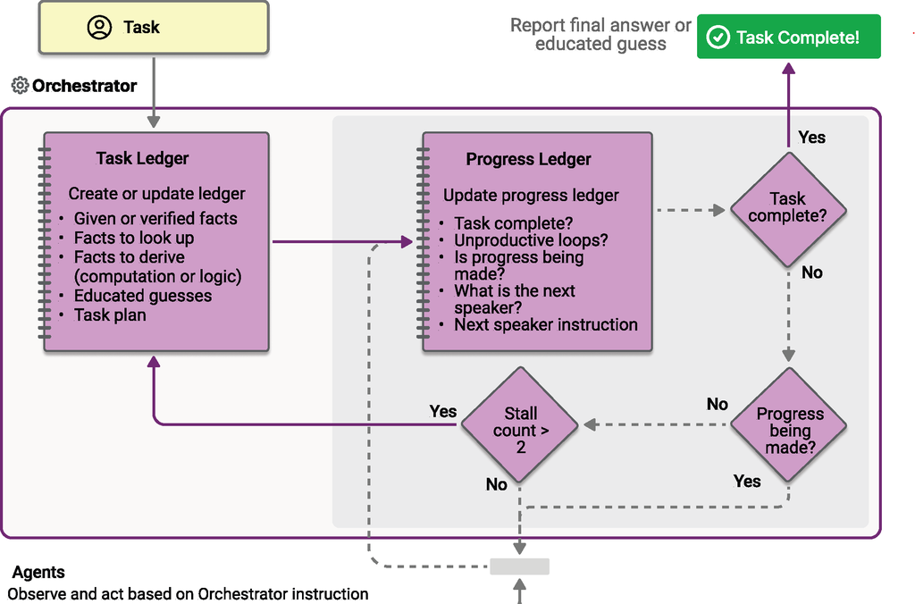

Il manager Magentic gestisce un contesto condiviso, tiene traccia dello stato di avanzamento e adatta il flusso di lavoro in tempo reale. Questo approccio consente al sistema di suddividere i problemi complessi, assegnare sottoattività e perfezionare in modo iterativo le soluzioni. Il processo si concentra tanto sulla costruzione e documentazione dell’approccio quanto sulla consegna della soluzione finale. Un libro mastro dinamico delle attività viene compilato e perfezionato man mano che il flusso di lavoro avanza, registra gli obiettivi, i sottogoal e i piani di esecuzione.

### 8.8.1 Quando usare l’orchestrazione Magentic

Prendere in considerazione l’uso del modello di orchestrazione Magentic in questi scenari:

- Il problema è complesso o aperto senza percorso di soluzione predeterminato.
- L’input e il feedback di più agenti specializzati sono necessari per modellare una soluzione valida.
- Il sistema deve generare un piano di approccio documentato per la revisione umana.
- Gli agenti dispongono di strumenti che possono interagire direttamente con sistemi e risorse esterni.
- Un piano di esecuzione compilato in modo dinamico aggiunge valore prima di eseguire le attività.

### 8.8.2 Quando evitare l’orchestrazione magnetica

È consigliabile evitare questo modello quando:

- Il percorso della soluzione è fisso o deterministico.
- Non è necessario produrre un libro mastro o un piano d’approccio.
- L’attività è abbastanza semplice da permettere l’uso di un pattern di orchestrazione più leggero.
- La velocità è la priorità, perché questo metodo enfatizza la pianificazione rispetto all’esecuzione rapida.
- Si prevedono blocchi o cicli frequenti senza un percorso di risoluzione chiaro.

### 8.8.3 Implementazione dell’orchestrazione magentica

Implementare il modello di orchestrazione Magentic con Microsoft Agent Framework:

1. **Definire agenti specializzati**: Creare istanze dell’agente (ad esempio, ChatAgent) con istruzioni specifiche e client di chat. Ogni agente deve avere un ruolo e funzionalità specializzati adatti a diversi aspetti dell’attività complessa.
2. **Configurare il callback per la gestione degli eventi**: Definire una funzione di callback asincrona per gestire diversi tipi di eventi durante l’orchestrazione, inclusi messaggi dell’orchestratore, aggiornamenti in streaming degli agenti, messaggi dell’agente e risultati finali.
3. **Creare il flusso di lavoro Magentic**: Usare la MagenticBuilder classe per creare l’orchestrazione. Aggiungere le istanze dell’agente come partecipanti, configurare il callback di evento con la modalità streaming e configurare il gestore standard con i parametri appropriati, ad esempio il numero massimo di round e i limiti di stallo.
4. **Configurare il gestore standard**: Il manager standard coordina la collaborazione degli agenti usando un client di chat per la pianificazione e il rilevamento dello stato. Configurare parametri come il numero massimo di round, il numero di stalli massime e il numero di ripristini per controllare il comportamento dell’orchestrazione.
5. **Eseguire il flusso di lavoro**: Chiamare il metodo run_stream del flusso di lavoro con l’attività complessa. Il flusso di lavoro pianifica in modo dinamico, delega il lavoro agli agenti appropriati e coordina la collaborazione per risolvere il problema.
6. **Eventi del workflow di processo**: Scorrere gli eventi del flusso di lavoro usando un ciclo asincrono. Gestire diversi tipi di eventi, tra cui WorkflowOutputEvent, che contiene i risultati finali dell’orchestrazione.
7. **Estrarre il risultato finale**: Raccogliere l’output finale dagli eventi del flusso di lavoro. Il risultato contiene la soluzione completa sviluppata attraverso lo sforzo collaborativo di tutti gli agenti partecipanti.

L’orchestrazione magentica eccelle nella risoluzione di problemi complessi e in evoluzione che richiedono un coordinamento in tempo reale tra agenti specializzati. È ideale per le attività in cui il piano non può essere definito in anticipo e deve adattarsi man mano che emergono nuove informazioni. Usando Microsoft Agent Framework, è possibile creare sistemi che progettano, affinano ed eseguono in modo dinamico i percorsi delle soluzioni tramite la collaborazione degli agenti intelligenti.

# 9 Individuare gli agenti di Intelligenza artificiale di Azure con A2A

## 9.1 Introduzione

Gli agenti AI sono di per sé potenti, ma molte attività reali richiedono la collaborazione tra più agenti. Il coordinamento manuale di queste interazioni può essere complesso, soprattutto quando gli agenti sono remoti o distribuiti.

Il protocollo A2A (Agent-to-Agent) risolve questo problema fornendo un framework standardizzato per l’individuazione dell’agente, la comunicazione e l’esecuzione coordinata di attività. Implementando A2A, è possibile gestire facilmente le connessioni agli agenti remoti, delegare le richieste all’agente appropriato e abilitare comunicazioni semplici, standardizzate e sicure tra gli agenti.

Si supponga, ad esempio, che un writer tecnico voglia creare contenuti di blog accattivanti. Un agente genera titoli di articoli interessanti, mentre un altro crea strutture dettagliate. Usando A2A, un agente di routing coordina il flusso di lavoro: invia la richiesta dell’utente all’agente del titolo, passa il titolo generato all’agente della struttura e restituisce la struttura finale all’utente, tutto automaticamente.

In questo modulo si apprenderà come implementare il protocollo A2A con gli agenti Azure AI. È anche possibile configurare un agente di routing, registrare gli agenti remoti e creare un flusso di lavoro coordinato che consenta a più agenti di collaborare in modo efficace.

## 9.2 Definire un agente A2A

Il protocollo da agente a agente (A2A) è un modo standardizzato per consentire agli agenti di intelligenza artificiale di comunicare e collaborare tra loro. Definisce il modo in cui gli agenti possono condividere il contesto, richiamare le funzionalità dell’altro e scambiare informazioni in modo sicuro. Rispettando il protocollo A2A, gli agenti di fornitori o piattaforme diversi possono collaborare senza problemi, consentendo soluzioni di intelligenza artificiale più complesse e integrate.

Prima che un agente A2A possa partecipare ai flussi di lavoro multi-agente, deve spiegare cosa può fare. Competenze dell’agente e modalità di esposizione di altri agenti o client tramite una scheda agente.

### 9.2.1 Vantaggi del protocollo da agente a agente (A2A)

Il protocollo da agente a agente (A2A) offre diversi vantaggi per le interazioni con l’agente di intelligenza artificiale:

- **Collaborazione avanzata**: A2A consente agli agenti di fornitori e piattaforme diversi di condividere il contesto e di collaborare, consentendo un’automazione senza interruzioni nei sistemi tradizionalmente disconnessi.
- **Selezione modello flessibile**: Ogni agente A2A può scegliere quale modello di linguaggio di grandi dimensioni usare per gestire le richieste, abilitando modelli ottimizzati o perfezionati per ogni agente, a differenza di alcuni scenari MCP che si basano su una singola connessione LLM.
- **Autenticazione integrata**: L’autenticazione è integrata nel protocollo A2A, fornendo un framework di sicurezza affidabile per la comunicazione da agente a agente sicuro.

### 9.2.2 Competenze dell’agente

Una competenza agente descrive una funzionalità o una funzione specifica che l’agente può eseguire. Si consideri un blocco predefinito che comunica con i client o altri agenti quali attività l’agente è progettato per gestire.

Gli elementi chiave di una competenza agente includono:

- **ID**: identificatore univoco per la competenza.
- **Nome**: nome leggibile che descrive la competenza
- **Descrizione**: spiegazione dettagliata delle operazioni della competenza.
- **Tag**: parole chiave per la categorizzazione e individuazione più semplice.
- **Esempi**: prompt di esempio o casi d’uso per illustrare la competenza in azione.
- **Modalità di input/output**: formati di dati o tipi di supporti supportati (ad esempio, testo, JSON).

Quando si definisce una competenza per l’agente, prendere in considerazione le attività da eseguire, come descriverle in modo chiaro e come altri agenti o client potrebbero usarle. Ad esempio, una semplice competenza “Hello World” potrebbe restituire un messaggio di saluto di base in formato testo, mentre una competenza di scrittura di blog potrebbe accettare un argomento e restituire un titolo o una struttura suggeriti.

### 9.2.3 Scheda agente

La scheda agente è come un biglietto da visita digitale per l’agente. Si tratta di un documento strutturato che un agente di routing o un client può recuperare per individuare le funzionalità dell’agente e come interagire con esso.

Gli elementi chiave di una scheda agente includono:

- **Informazioni sull’identità**: nome, descrizione e versione dell’agente.
- **URL endpoint**: dove è possibile accedere al servizio A2A dell’agente.
- **Funzionalità**: funzionalità di A2A supportate, ad esempio lo streaming o le notifiche push.
- **Modalità di input/output predefinite**: i tipi di supporti primari che l’agente può gestire.
- **Competenze**: elenco delle competenze dell’agente che altri agenti possono richiamare.
- **Supporto dell’autenticazione**: indica se l’agente richiede credenziali per l’accesso.

Quando si crea una scheda agente, assicurarsi che rappresenti in modo accurato le competenze e gli endpoint dell’agente. In questo modo i client o gli agenti di routing possono individuare l’agente, comprendere cosa può fare e interagire con esso in modo appropriato.

### 9.2.4 Metterlo insieme

Dopo che un agente definisce le proprie competenze e pubblica una scheda agente:

- Altri agenti o client possono individuare automaticamente l’agente.
- Le richieste possono essere indirizzate alla competenza appropriata dell’agente.
- Le risposte vengono restituite in formati supportati, consentendo una collaborazione uniforme tra più agenti.

Ad esempio, in un flusso di lavoro di writer tecnico, un agente può definire le competenze per la generazione di titoli degli articoli e un altro per la creazione di contorni. L’agente di routing recupera la scheda di ogni agente per individuare queste funzionalità e orchestra un flusso di lavoro in cui un titolo generato da un agente inserisce nell’agente struttura, producendo una risposta finale coesa.

## 9.3 Implementare un executor dell’agente

Agent Executor è un componente principale di un agente A2A. Definisce il modo in cui l’agente elabora le richieste in ingresso, genera risposte e comunica con client o altri agenti. Si consideri il bridge tra il protocollo A2A e la logica di business specifica dell’agente.

### 9.3.1 Informazioni sull’executor dell’agente

L’interfaccia `AgentExecutor` gestisce tutte le richieste in ingresso inviate all’agente. Riceve informazioni sulla richiesta, la elabora in base alle funzionalità dell’agente e invia risposte o eventi tramite un canale di comunicazione.

Responsabilità chiave:

- Eseguire attività richieste da utenti o altri agenti.
- Trasmettere risposte o inviare singoli messaggi al client.
- Gestire l’annullamento delle attività, se supportato.

### 9.3.2 Implementare l’interfaccia

Un executor di Agent definisce in genere due operazioni principali:

**Eseguire**

- Elabora le richieste in ingresso e genera risposte.
- Accede ai dettagli della richiesta( ad esempio, input dell’utente, contesto dell’attività).
- Invia i risultati tramite una coda di eventi, che può includere messaggi, aggiornamenti delle attività o artefatti.

**Annullare**

- Gestisce le richieste per annullare un’attività in corso.
- Potrebbe non essere supportato per gli agenti semplici.
- L’executor usa RequestContext per comprendere la richiesta in ingresso e un oggetto EventQueue per comunicare i risultati o gli eventi al client.

### 9.3.3 Flusso di gestione delle richieste

Si consideri un flusso di lavoro dell’agente “Hello World”:

1. L’agente ha una piccola classe helper che implementa la logica di base, ad esempio la restituzione di una stringa.
2. L’executor riceve una richiesta e chiama la logica dell’agente.
3. L’executor incapsula il risultato come evento e lo inserisce nella coda di eventi.
4. Il meccanismo di routing invia di nuovo l’evento al richiedente.

Per l’annullamento, un agente di base potrebbe indicare che l’annullamento non è supportato.

Agent Executor è fondamentale per rendere funzionale l’agente A2A. Definisce il modo in cui l’agente esegue le attività e comunica i risultati, fornendo un’interfaccia standardizzata per i client e altri agenti. Gli executor implementati correttamente consentono l’integrazione e la collaborazione senza problemi nei flussi di lavoro multi-agente.

## 9.4 Ospitare un server A2A

Dopo che l’agente ne definisce le competenze e la scheda agente, il passaggio successivo consiste nell’ospitarlo in un server. L’hosting rende l’agente accessibile ai client e ad altri agenti tramite HTTP, consentendo interazioni in tempo reale e flussi di lavoro multi-agente.

L’hosting di un agente consente di:

Presentare le sue funzionalità tramite la scheda agente, che i clienti e altri agenti possono individuare. - Ricevere le richieste A2A in ingresso e inoltrarle al Agent Executor per l’elaborazione. - Gestire i cicli di vita delle attività, incluse le risposte in streaming e le interazioni con stato. In effetti, il server funge da ponte tra la logica dell’agente e il mondo esterno, assicurandosi che possa partecipare a flussi di lavoro coordinati.

### 9.4.1 Componenti di base del server agente

Per ospitare un agente, sono necessari tre componenti essenziali che interagiscono:

**Scheda agente**

- Descrive le funzionalità, le competenze e le modalità di input/output dell’agente.
- Pubblicato su un endpoint standard (tipicamente /.well-known/agent-card.json) affinché i client e altri agenti possano individuare il tuo agente.
- Può includere più versioni o una scheda “estesa” per gli utenti autenticati.

**Gestore richieste**

- Indirizza le richieste in ingresso ai metodi appropriati nell’executor dell’agente (ad esempio, execute o cancel).
- Gestisce il ciclo di vita delle attività usando un Archivio attività, che tiene traccia delle attività, dei dati in streaming e delle sottoscrizioni.
- Anche gli agenti semplici richiedono un archivio attività per gestire in modo affidabile le interazioni.

**Applicazione server**

- Compilato usando un framework Web (Starlette in Python) per gestire le richieste HTTP.
- Combinato con un server ASGI (ad esempio Uvicorn) per avviare l’ascolto su un’interfaccia di rete e una porta.
- Espone la scheda agente e gli endpoint del gestore delle richieste, consentendo ai client di interagire con l’agente.

### 9.4.2 Configurare il server dell’agente A2A

1. Definire le competenze dell’agente e la scheda agente.
2. Inizializza un Gestore di richieste che collega l’executor dell’agente a un archivio attività.
3. Configurare l’applicazione server, specificando la scheda agente e il gestore delle richieste.
4. Avviare il server usando un server ASGI (Uvicorn) per renderlo accessibile sulla rete.
5. Una volta in esecuzione, l’agente ascolta le richieste in ingresso e risponde in base alle competenze definite.

Un agente “Hello World” può esporre un’abilità di saluto di base. Una volta ospitata, può rispondere a tutte le richieste inviate al relativo endpoint. Un agente più complesso può offrire più competenze o una scheda agente estesa per gli utenti autenticati.

L’hosting di un agente A2A combina la scheda agente, il gestore delle richieste e l’executor dell’agente, rendendole disponibile per interazioni tra client e agenti. Questa configurazione garantisce che le attività vengano gestite correttamente e le risposte vengano recapitate in modo affidabile, consentendo all’agente di partecipare ai flussi di lavoro multi-agente.

## 9.5 Connettersi all’agente A2A

Quando il server agente A2A è in esecuzione, il passaggio successivo consiste nel comprendere come un client può interagire con esso. Un client funge da ponte tra l’applicazione e il server agente.

Le responsabilità del cliente includono:

- Individuazione della scheda agente, che contiene i metadati relativi all’agente e ai relativi endpoint.
- Invio di richieste all’agente per l’elaborazione.
- Ricezione e interpretazione delle risposte dell’agente, che possono essere messaggi diretti o risultati basati su attività.

### 9.5.1 Connettersi al server agente

- Il client deve conoscere l’URL di base del server.
- Il client recupera in genere la scheda agente da un endpoint noto nel server.
- Dopo aver ottenuto la scheda agente, il client può essere inizializzato con esso, stabilendo una connessione pronta per l’invio di messaggi.

### 9.5.2 Inviare richieste all’agente

Esistono due tipi principali di richieste che un client può effettuare:

- **Richieste non di streaming**: Il client invia un messaggio e attende una risposta completa. Questo tipo di richiesta è adatto per interazioni semplici o quando è prevista una singola risposta.
- R**ichieste di streaming**: Il client invia un messaggio e riceve le risposte in modo incrementale mentre l’agente elabora la richiesta. Questo tipo di richiesta è utile per le attività a esecuzione prolungata o quando si vuole aggiornare l’utente in tempo reale.

In entrambi i casi, le richieste in genere includono un role (ad esempio, utente) e il contenuto del messaggio. Gli agenti più complessi possono restituire oggetti attività anziché messaggi immediati, consentendo il rilevamento o l’annullamento delle attività.

### 9.5.3 Gestire la risposta dell’agente

Le risposte dell’agente possono includere:

- **Messaggi diretti**: Output immediati dell’agente, ad esempio testo o contenuto strutturato.
- **Risposte basate su attività**: Oggetti che rappresentano attività in corso, che possono richiedere chiamate di completamento per controllare lo stato o recuperare i risultati.

I client devono essere preparati a gestire entrambi i tipi di risposta e interpretare i dati restituiti in modo appropriato.

### 9.5.4 Interazione con l’agente

- Ogni richiesta deve essere identificabile in modo univoco, spesso usando un ID generato.
- Le risposte di streaming sono asincrone e possono fornire risultati parziali prima dell’output finale.
- Gli agenti semplici possono restituire messaggi direttamente, mentre gli agenti più avanzati possono gestire più attività contemporaneamente.

La connessione di un client al server agente comporta il recupero della scheda agente, la definizione di una connessione, l’invio di richieste e la gestione delle risposte. Comprendendo questi concetti di base, è possibile interagire in modo sicuro con l’agente remoto, indipendentemente dal fatto che si inviino messaggi semplici o si gestiscono attività complesse.